# EHV-1 Genes’ transcript ratios

Balázs Kakuk

[output not shown]

# Project info

*Samples: dcDNA Seq*  
*pychopper: no*  
*mapping version: v6*  
*LoRTIA: yes (stranded only)*

*Filtering samples: C6_2h_3 & PC-12_8h_3*

## Only those reads were counted, where LoRTIA found *both* 5- and 3-prime adapters!

## Correct some genes in the annotation

DO NOT Filter second copies of genes, as in some cases there are transcripts from only one of the copies

# Counts based on iterative GFF-compare results

This was done as follows:

1. The reference transcripts were compared individually/iteratively to the reads.
2. The distances between the reads and each reference transcript hit were calculated.
3. For each read, the most similar reference transcript was assigned (lowest distance).
4. Additionally, these distances must had fulfill the following rules: *max prime5 distance <= 10*  
   *max prime3 distance <= 10*  
   *exon/intron junction difference <= 2*
5. Thus based on these, the read counts for each reference transcript were assessed.
6. The transcripts were then assigned to their parent genes (by Torma G) and their ratio (isoform ratio) was calculated as follows:  
   *isoform ratio = transcript isoform count / total gene count*
7. Those reads that could not be assigned to the reference transcripts were assigned to their parent genes, based on their 5-prime ends and independently to their parent gene cluster, based on their 3-prime ends.  
   So the reads are either:
- assigned to a reference transcript
- could not not be assigned to a ref TR, in which case they were:
  1. assigned to their parent gene based on their *5-prime* end overlapping with the gene’s *TSS*
  2. assigned to their parent gene-cluster based on their *3-prime* end overlapping with the cluster’s *TES*
  3. assigned to both

## 1. Kinetics of Reference Transcript Isoforms, according to their host gene

The reads were assigned to their parent gene based on their *5-prime* end overlapping with the gene’s *TSS*  
(but not necessarily with the gene cluster’s TES)

Merge annotation with RefClass

Exclude those ref transcripts that were not observed (or observed under the threshold) from the annotation as well

## Evaluate CAGE against dcDNA read counts

```
## Key: <transcript_id>
## Empty data.table (0 rows and 36 cols): transcript_id,CAGE_ID,score,support,CAGE_significance,seqnames...
```

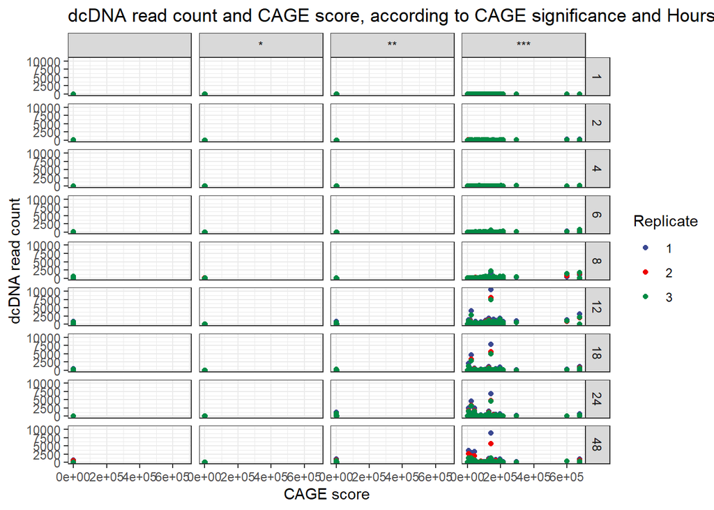

```
##        gene     N
##      <char> <int>
##  1:     CTO  7799
##  2:    NOIR 10766
##  3:    ORF1  3004
##  4:   ORF10  2242
##  5:   ORF11 13394
##  6:   ORF12  7041
##  7:   ORF13  1437
##  8:   ORF14 17457
##  9:   ORF19  9218
## 10:   ORF23  6801
## 11:   ORF24  8431
## 12:   ORF28   479
## 13:   ORF27  1650
```

[output cut: 67 more lines]

```
##      gene class_code     N
##    <char>     <char> <int>
## 1:   <NA>          =    58
```

```
## Key: <gene>
##        gene 3`-long 3`-short 5`-long 5`-short     = Splice-variant     c     e
##      <char>   <int>    <int>   <int>    <int> <int>          <int> <int> <int>
##  1:    <NA>     207      256      59      309    58             14   388     2
##  2:     CTO      93       61    1790     2085   424            681    85    NA
##  3:    NOIR     166       62    1522      784   531            123   388  1645
##  4:    ORF1      12       97     534     1237   159             79    79    NA
##  5:   ORF10      32      228     145      755   221             81   130    NA
##  6:   ORF11     115      450    1883     6530   660            207   957    NA
##  7:   ORF12      59      451     382     3904   238            140   619    NA
##  8:   ORF13       2      448      48      148   122            402    17    NA
##  9:   ORF14       5      907    2739     4325   412            281  2780    NA
## 10:   ORF15      20      970    3282     3008   355            255   327    NA
## 11:   ORF16      11      983     182      773   419            356    79    NA
## 12:   ORF17      90      133     154     2397   145              7   293    NA
```

[output cut: 150 more lines]

[figure not shown]

[figure not shown]

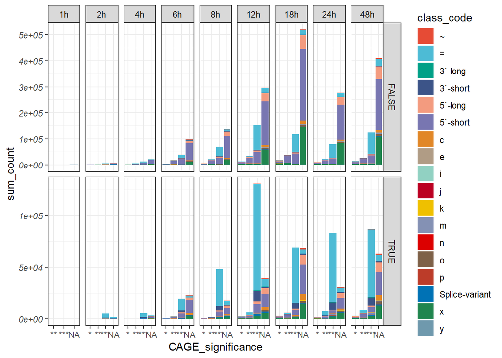

[figure not shown]

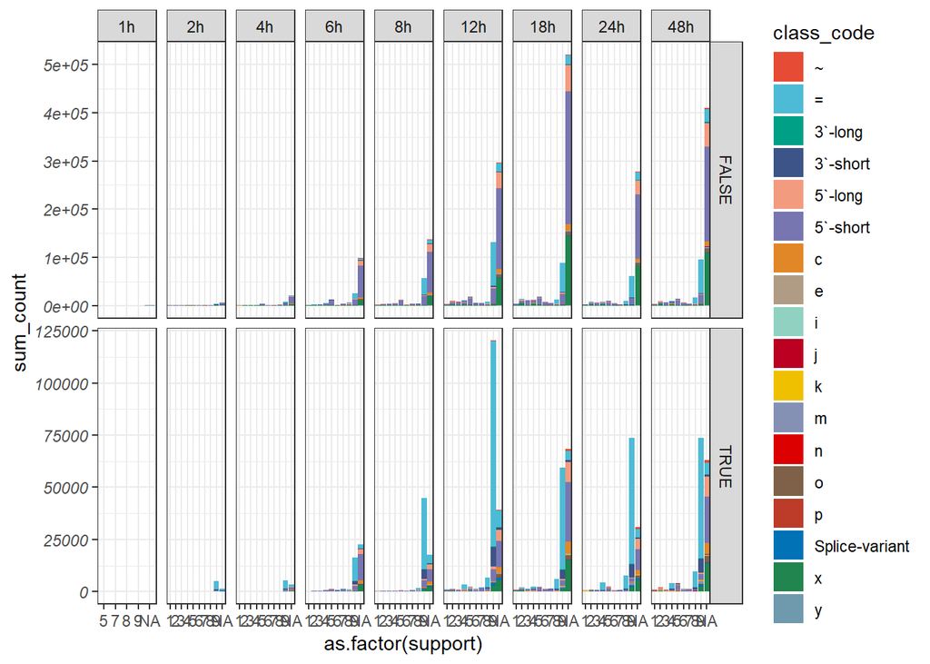

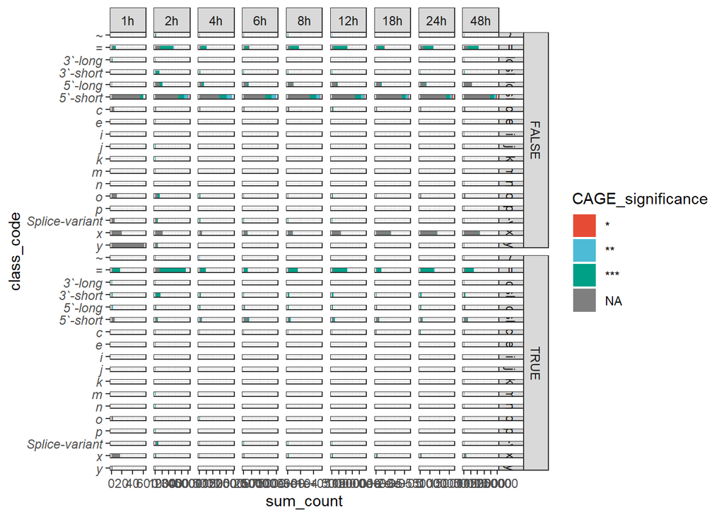

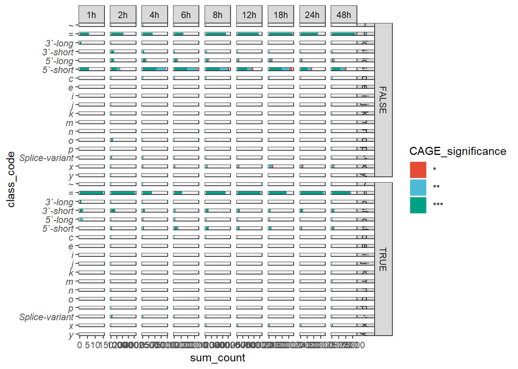

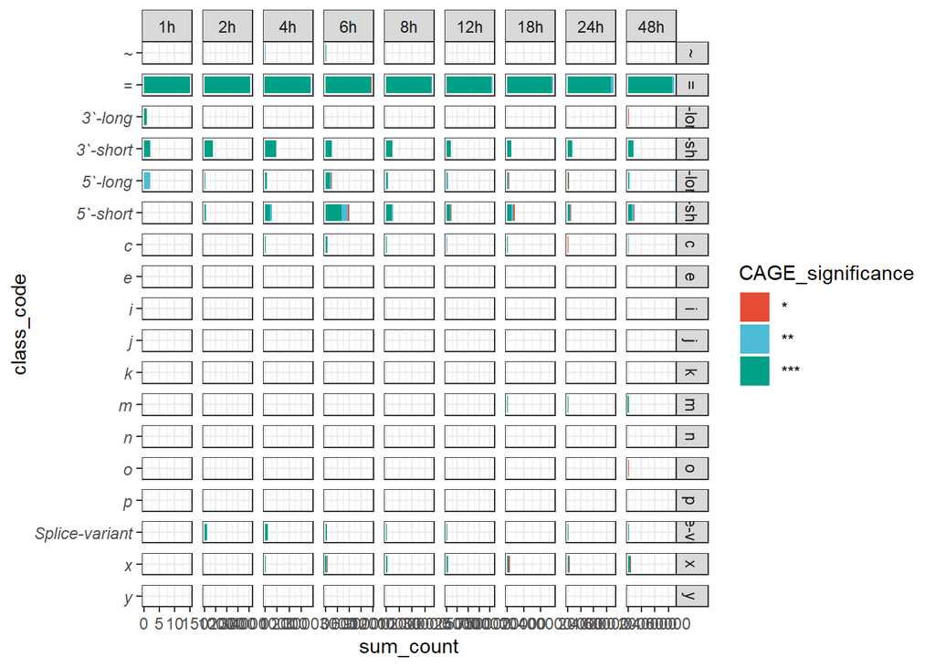

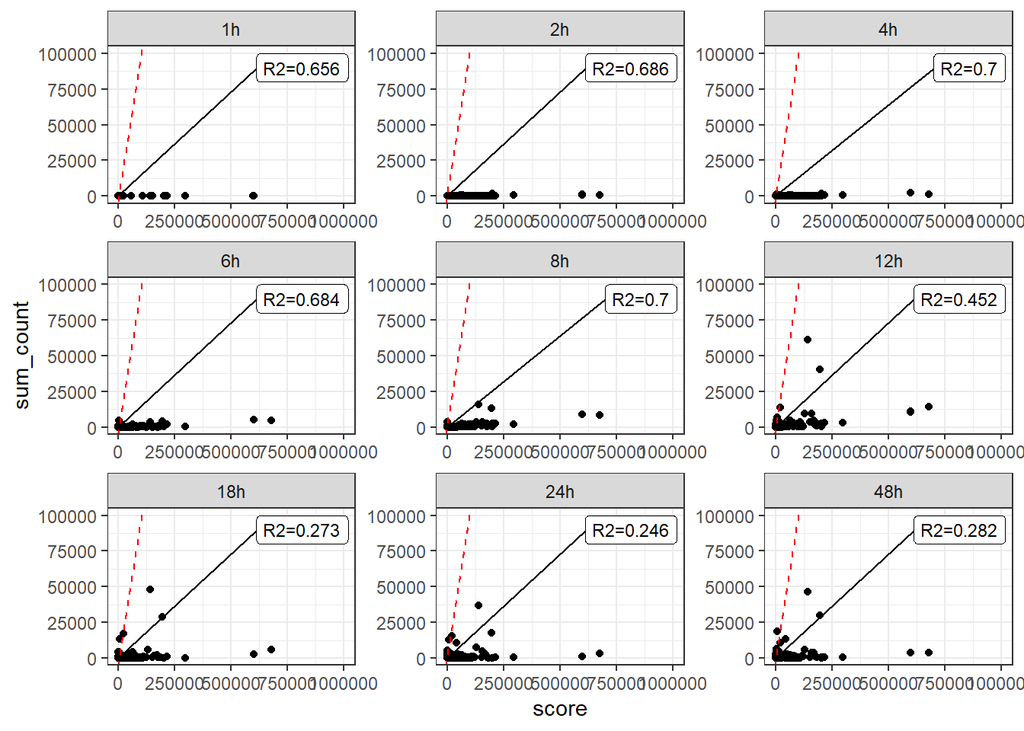

There are many transcripts that were identifed with CAGE, and have a high read count in the dcDNA but are novel (not in the reference). They are not the product of false 5-prime sites as they have correct TSS adapaters. Most of these are antisense or 5-prime short but there are 5-prime longs (both shere the 4-primes with ref transcripts) and ‘c’ as well (which have different 3-primes)

Lets check them gene-wise The 5-prime long and short variants.

[figure not shown]

Select TSS clusters that are significant (non-NA) in the CAGE results AND have sufficient read counts in the dcDNA reads as well, from where their 5-prime ends were correct and their class-code based on gff-compare was either 5-prime short or long.

```
##  [1]  954 1224 2246 2261 3011 3014 3327 4014 3344 3394 3458 2228 3385   96  132
## [16]  134  166  193  413  415  657  687  704  725  805 1105 1354 1477 1496 1715
## [31] 1733 2337 3343 1004 2714  275  313  400  500  644  771  878 1027 1542 1894
## [46] 2185 2308
```

```
## [1] TRUE
```

[figure not shown]

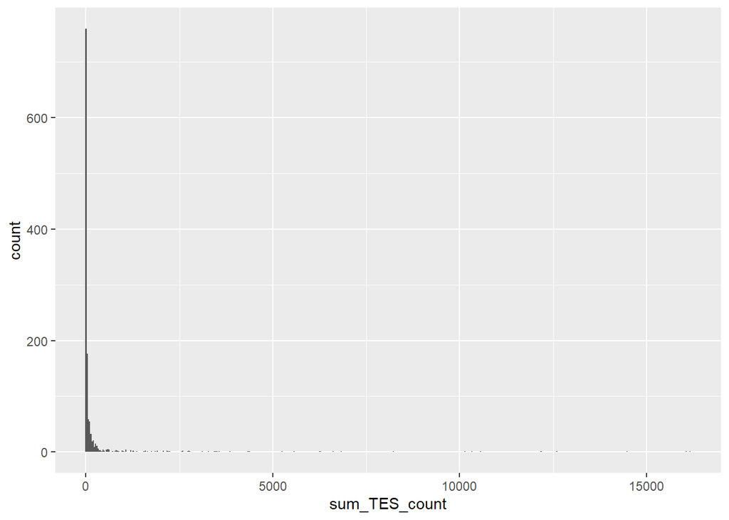

```
## [1] 1254
```

```
## [1] 1039
```

```
## [1] 785
```

```
## [1] 613
```

```
## [1] 463
```

```
## [1] 315
```

```
##     CAGE_significance support     N
##                <char>   <int> <int>
##  1:                **       3    93
##  2:               ***       3    68
##  3:                **       5    86
##  4:                 *       2   266
##  5:                 *       1   434
##  6:                **       4    84
##  7:               ***       7    47
##  8:               ***       9    80
##  9:               ***       8    43
## 10:               ***       6    53
```

Annotation plotting function

## With annnotation

### Tests

[output not shown]